# Learning from Machines:

Differentiating US Presidential Campaigns with Attribution and Annotation

Musashi Jacobs-Harukawa (he/him)

University of Oxford

Presented 17 June 2022 at PaCSS

# tl;dr

- **Objective**: differentiate language of political actors
- **Method**: feature attribution on DL language models
- **Advantage**: model sequence-level differences
- **Innovation**: validation and application
- **Application**: 12 Presidential ad campaigns on FB

# Task and Challenge

## Broad Methodological View

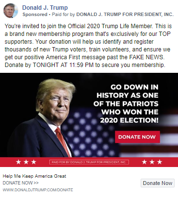

- Plain description versus descriptive inference
- Characterization as a form of inference
- Differentiation as a form of characterization
- Micro: *What makes this ad a Trump ad?*
- Macro: *What are Trump ads like?*

## An Existing Approach

- Fightin’ Words (Monroe, Colaresi, and Quinn 2008)
- Example: US legislators abortion debate
  - Republican tokens: `kill`, `babi`, `mother`
  - Democrat tokens: `woman`, `decis`, `viabil`
- Can infer framing strategy (Chong and Druckman 2007)
- What about `doctor` or `procedur`?

## Two Common Steps

- Discard order
  - Term-Document Matrix: Wordfish, topic models, etc.
  - Local context window: Word2Vec
  - Term-Co-occurrence Matrix: GloVe
- Output numeric summaries
  - Token weights
  - Document weights

## Linking Estimands

- *Everything is Lexical Semantics*
- Theoretical-empirical link via meaning of words
  - Substantive interpretation: word
  - Prevalence/existence: number/statistic

## Challenges

- Validation
  - Numeric reduction removes context
  - Word sense resolution challenging
- Limits
  - Other linguistic phenomena exist
  - How to model linguistic phenomena produced by order?

# Alternative

## The Pitch

- Train `BERT`(-like) to classify ads by campaign
- Ask `BERT` what the differentiating features are
- Annotate source texts to highlight differentiating language

## What’s a `BERT`? (Devlin et al. 2019)

- Family of transformer-based deep neural network sequence encoders
- *Deep Learning*: complex multilayered neural network
- *Sequence Encoder*: text → sequence of vectors

## Why ask a `BERT`?

- Excel at generating task-specific embeddings with minimal training
- *Transfer Learning*: train on large corpus, fine-tune on small corpus
- *Linguistic Knowledge*: syntax (Lin, Tan, and Frank 2019), semantics (Ettinger 2020)
- *Superhuman Accuracy*: (Linardatos, Papastefanopoulos, and Kotsiantis 2021; Storks and Chai 2021)

## How to ask a `BERT`?

- *Black Box*:
  - Large number of parameters (`BERT`-base has 110 million)
  - Intermediary weights have no straightforward interpretation
- *Feature Attribution*:
  - Ask `BERT` which parts of the document inform its predictions
  - Use feature attribution to get per-token scores

## Feature Attribution

*Integrated Gradients* (Sundararajan, Taly, and Yan 2017)

- DL analog of decomposing OLS prediction into partial derivatives wrt inputs
- +ve IG indicates feature “contributes” to +ve class
- -ve IG indicates feature “contributes” to -ve class
- 0 IG indicates no contribution
- Relative magnitudes matter, absolute hard to interpret

## How do we know this works?

*We care about validation!*

- Statistical: uncertainty measure of IG score
- Substantive: how can we be know high-IG spans *matter*?
  - Compare to existing methods
  - Novel validation strategy

## Confidence Intervals

*Monte Carlo Dropout* (Gal and Ghahramani 2016)

- Most DL architectures include random dropout layers
- Can be used as computationally efficient bootstrap
- I generate 30 draws, then bootstrap over these

## Validation by Sufficiency

Based on Jain et al. (2020) (FRESH)

1. Train text classifier
2. Use IG to extract high-salience regions (rationales)
3. Train two further models:
   - One only sees rationales
   - Other only sees text-sans-rationales

## Strategy Summarized

| Model Trained | Model Accuracy | Strategy Precision | Strategy Recall |
| --- | --- | --- | --- |
| rationale | high | high | – |
| text-sans-rationale | low | – | high |

## How do we use these scores?

- *Tired*: Token Weights
  - Can be aggregated
  - Can be compared with established tools
- *Wired*: Document Annotation
  - Within-sample characterization
  - Highlight differentiating regions of texts
- *Inspired*: Hybrid Qualitative-Quantitative Approach
  - Prepare texts with annotations to guide analysis.

## Challenge: “Artefacts”

- If model accurate, highlighting patterns actually differentiating. But!
- Model has no sense of “useful” differentiation
  - may just be “artefacts”
- How much to trust the machine?
  - Solution requires researcher judgment

# Application

## Data

- ProPublica Political Facebook Ads (2016-2020, US)
- Twelve US presidential ad campaigns
- Fuzzy duplicate removal using Levenshtein similarity

## Three Comparisons

| Comparsion | Purpose | N |
| --- | --- | --- |
| Trump vs Biden | Proof-of-concept, sense check | 527 |
| Sanders vs Warren | Difficult binary | 829 |
| 11 Democratic Primary | Multiclass | 3,165 |

## Parameters

- Non-destructive: No lowercasing or stopword removal
- LO/FW pre-lemmatized, IG post-lemmatized for comparison
- Tokenizer: `RoBERTa` byte-pair encoding subword tokenization
- Learning rates $3e-4$ to $5e-5$
- All choices checked for implementation invariance

# Results

## Validation 1: Comparison

- IG has weak correlation with LO and FW
- Qualitative judgment of diverging results unclear
- Hard to say what is a better “summary” for this task.

## Validation 2: FRESH

- FRESH strategy shows annotation are relevant information
- CIs confirm scores sufficiently stable

## Rationale Extraction

[interactive chart not shown]

## Output: Annotated Ads

[interactive chart not shown]

## Sanders vs Warren vs Rest

[interactive chart not shown]

# Next Steps

- Software to make pipeline available to non-technical users
- Methodology for hybrid AI-augmented qualitative text analysis
- Further uses for model logic beyond annotation?

# References

Chong, Dennis, and James N Druckman. 2007. “Framing public opinion in competitive democracies.” *American Political Science Review* 101 (4): 637–55.

Devlin, Jacob, Ming-Wei Chang, Kenton Lee, and Kristina Toutanova. 2019. “BERT: Pre-training of Deep Bidirectional Transformers for Language Understanding.” In *Proceedings of the 2019 Conference of the North American Chapter of the Association for Computational Linguistics: Human Language Technologies, Volume 1 (Long and Short Papers)*, 4171–86. Minneapolis, Minnesota: Association for Computational Linguistics. https://doi.org/10.18653/v1/N19-1423.

Ettinger, Allyson. 2020. “What BERT is not: Lessons from a new suite of psycholinguistic diagnostics for language models.” *Transactions of the Association for Computational Linguistics* 8: 34–48.

Gal, Yarin, and Zoubin Ghahramani. 2016. “Dropout as a bayesian approximation: Representing model uncertainty in deep learning.” In *international conference on machine learning*, 1050–59. PMLR.

Jain, Sarthak, Sarah Wiegreffe, Yuval Pinter, and Byron C. Wallace. 2020. “Learning to Faithfully Rationalize by Construction.” In *Proceedings of the 58th Annual Meeting of the Association for Computational Linguistics*, 4459–73. Online: Association for Computational Linguistics. https://doi.org/10.18653/v1/2020.acl-main.409.

Lin, Yongjie, Yi Chern Tan, and Robert Frank. 2019. “Open Sesame: Getting inside BERT’s Linguistic Knowledge.” In *Proceedings of the 2019 ACL Workshop BlackboxNLP: Analyzing and Interpreting Neural Networks for NLP*, 241–53. Florence, Italy: Association for Computational Linguistics. https://doi.org/10.18653/v1/W19-4825.

Linardatos, Pantelis, Vasilis Papastefanopoulos, and Sotiris Kotsiantis. 2021. “Explainable AI: A Review of Machine Learning Interpretability Methods.” *Entropy* 23 (1). https://doi.org/10.3390/e23010018.

Monroe, Burt L, Michael P Colaresi, and Kevin M Quinn. 2008. “Fightin’words: Lexical feature selection and evaluation for identifying the content of political conflict.” *Political Analysis* 16 (4): 372–403.

Storks, Shane, and Joyce Chai. 2021. “Beyond the Tip of the Iceberg: Assessing Coherence of Text Classifiers.” In *Findings of the Association for Computational Linguistics: EMNLP 2021*, 3169–77. Punta Cana, Dominican Republic: Association for Computational Linguistics. https://doi.org/10.18653/v1/2021.findings-emnlp.272.

Sundararajan, Mukund, Ankur Taly, and Qiqi Yan. 2017. “Axiomatic attribution for deep networks.” In *International conference on machine learning*, 3319–28. PMLR.